# Estudios de Informática, Multimedia y Telecomunicaciones

Realizamos la conversión u observamos los resultados:

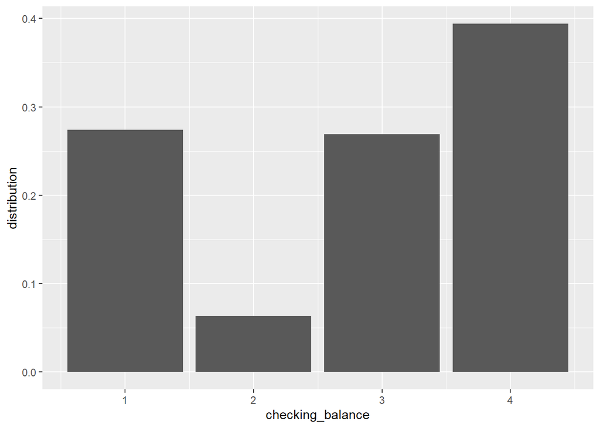

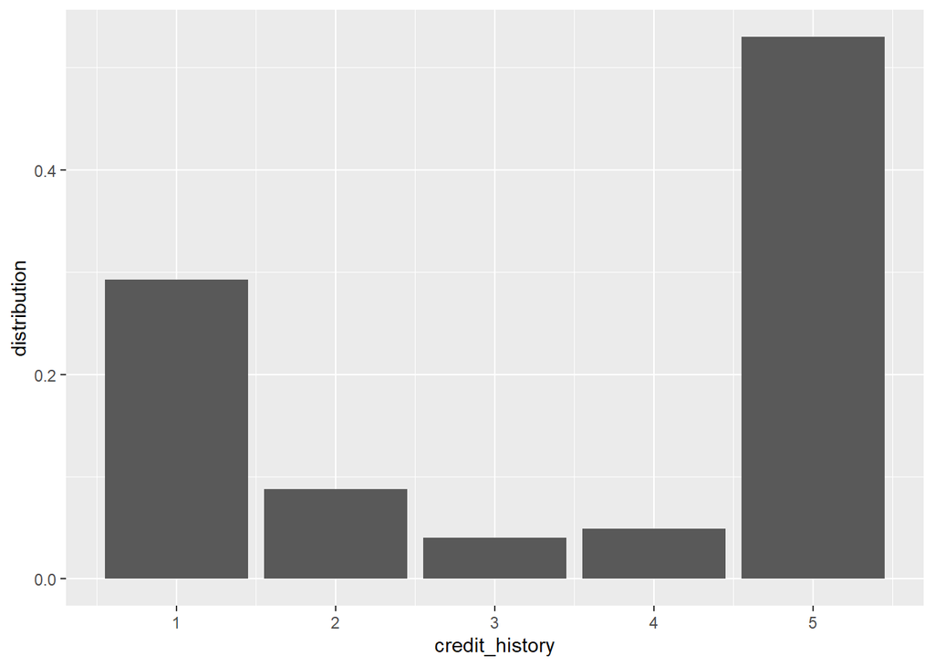

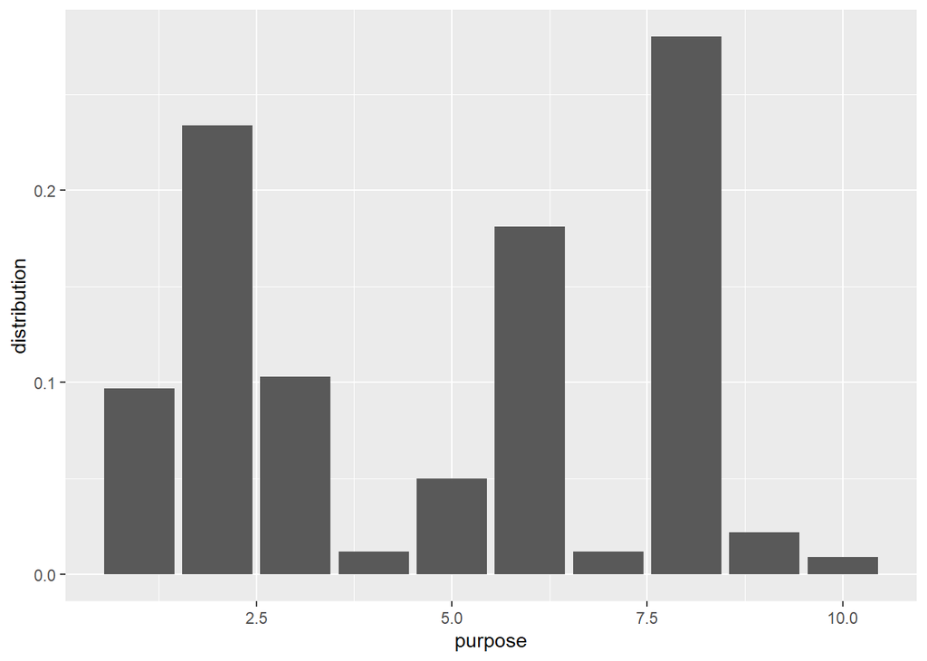

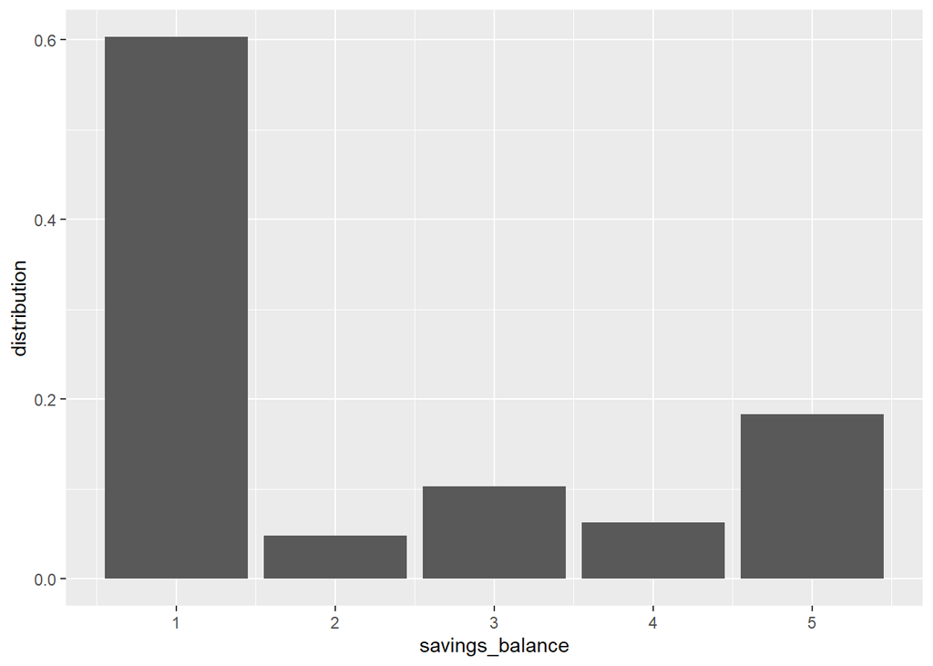

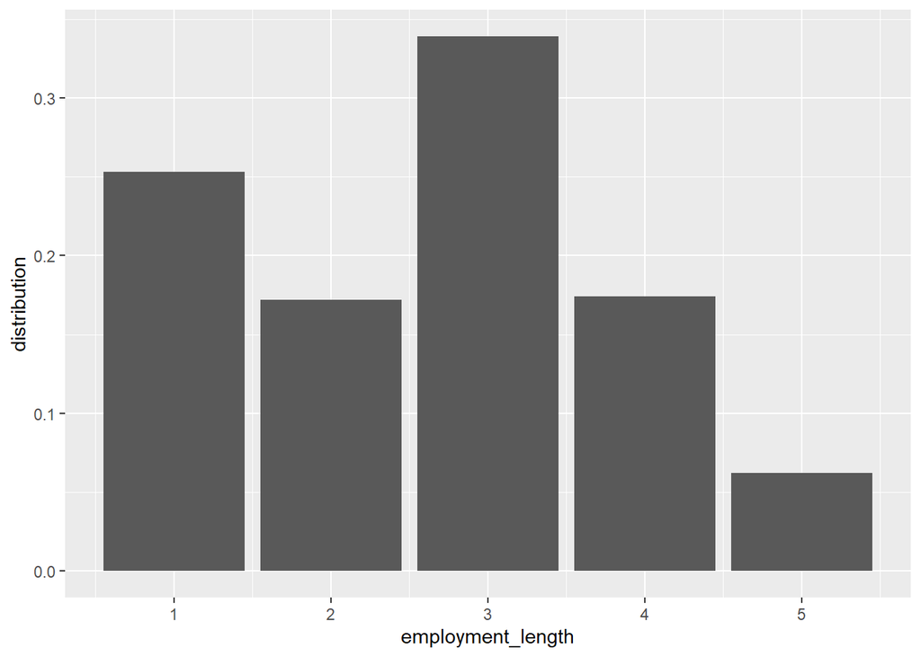

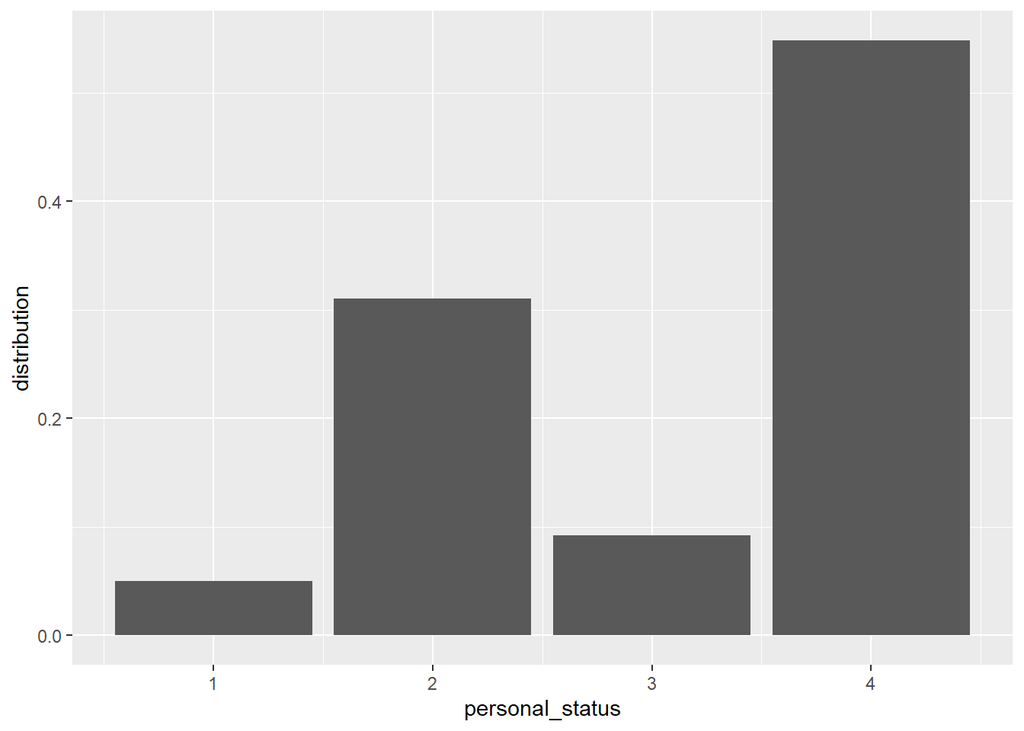

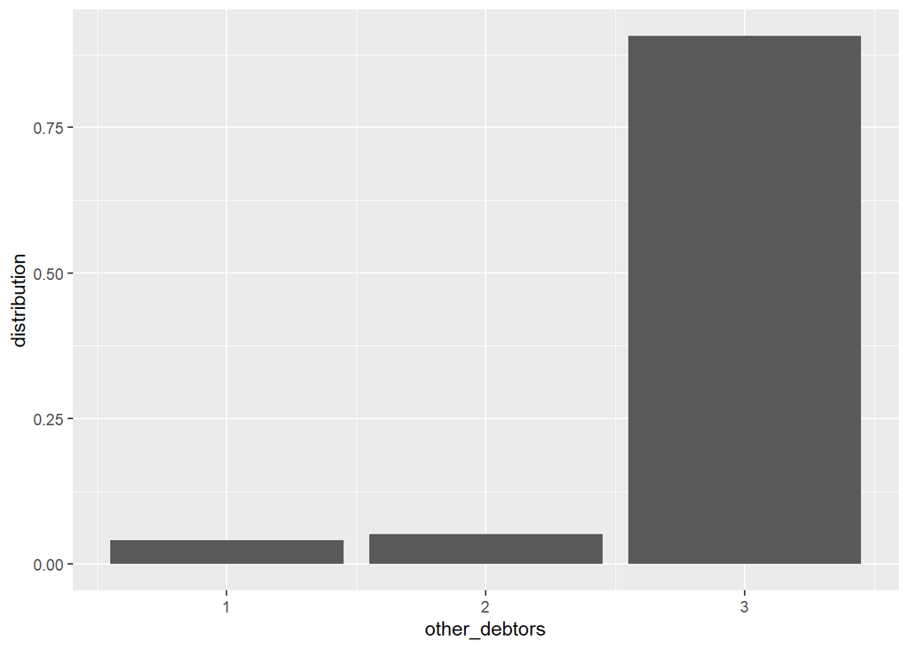

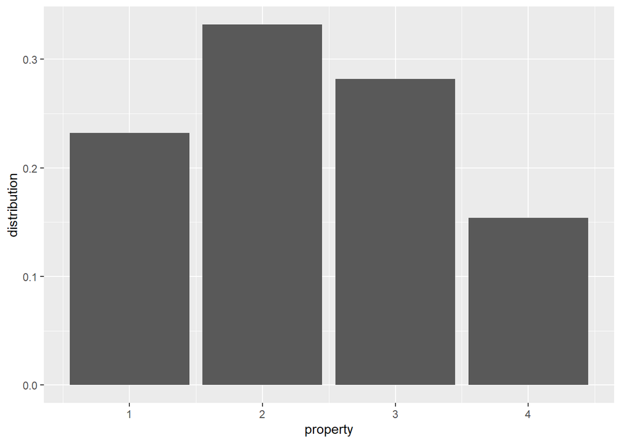

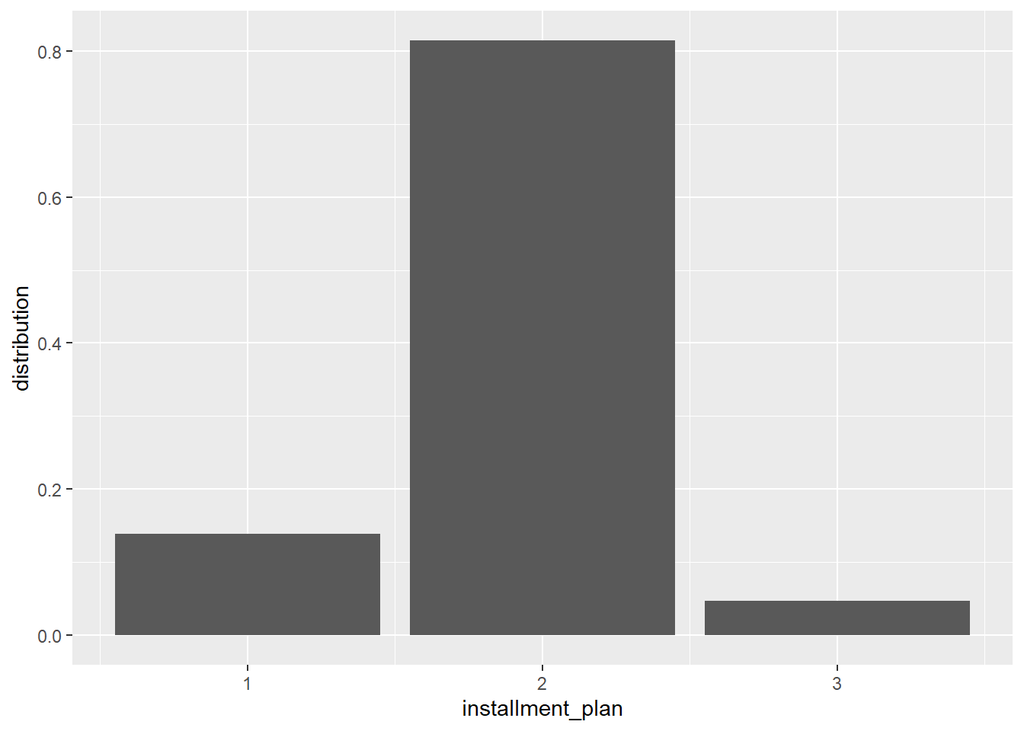

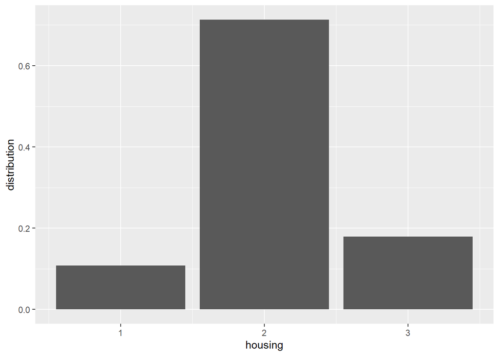

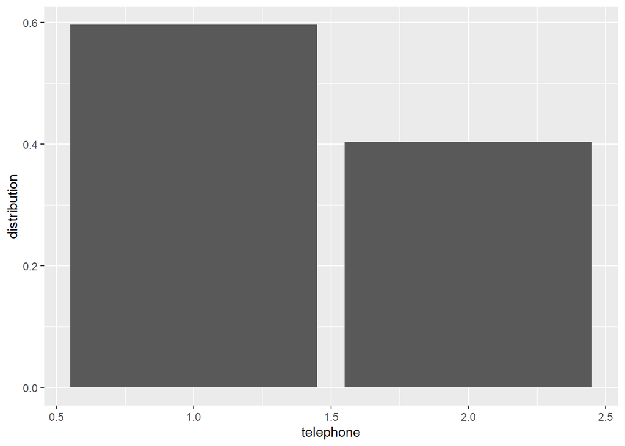

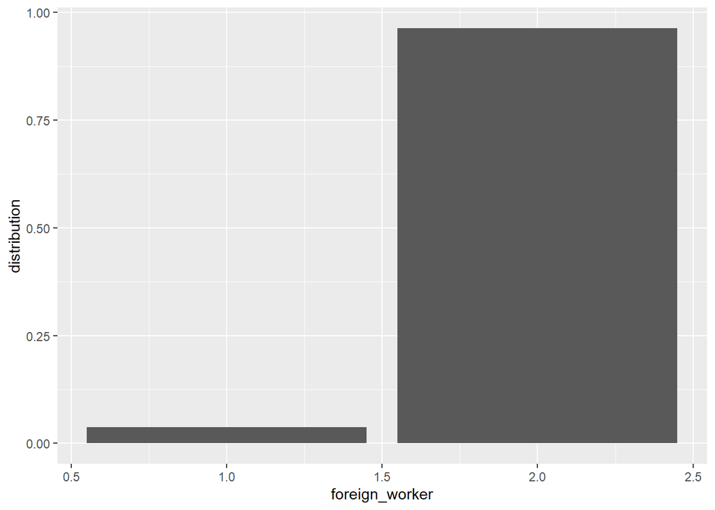

[1 more figures not shown]

```r
for(y in categoriesList){
  ggp <- ggplot(conjunto_datos[y], aes_string(x = y)) +
         geom_bar(aes(y = (..count..)/sum(..count..))) +
        ylab("distribution")
  print(ggp)
}
```

###### 1.2.2.1.2.3 ORDENANDO CATEGORÍAS

**checking_balance**

Además, categorías desordenadas que podrían perturbar un futuro análisis, especificamente la categoría “> 200 DM”.

```r
conjunto_datos <- mutate(conjunto_datos, checking_balance =
                          ifelse(checking_balance==2, 5,
                                 ifelse(checking_balance==3, 2, checking_balance
                                )
                                )
);
```

```r
conjunto_datos <- mutate(conjunto_datos, checking_balance =
                          ifelse(checking_balance==5, 3, checking_balance
                                )
);
```

**savings_balance**

Presenta categorías desordenadas que podrían perturbar un futuro análisis, especificamente la categoría “> 1000 DM”.

```r
conjunto_datos <- mutate(conjunto_datos, savings_balance =
                          ifelse(savings_balance==2, 6,
                                 ifelse(savings_balance==3, 2,
                                        ifelse(savings_balance==4, 3, savings_balance
                                )
                                )
                                )
);
```

```r
conjunto_datos <- mutate(conjunto_datos, savings_balance =
                          ifelse(savings_balance==6, 4, savings_balance
                                )
)
```

**employment_length**

Presenta categorías desordenadas que podrían perturbar un futuro análisis, especificamente las categorías “>7 years” y “unemployed”.

```r
conjunto_datos <- mutate(conjunto_datos, employment_length =
                          ifelse(employment_length==1, 6,
                                 ifelse(employment_length==5, 1, employment_length
                                )
                                )
);
```

```r
conjunto_datos <- mutate(conjunto_datos, employment_length =
                          ifelse(employment_length==6, 5, employment_length
                                )
)
```

#### 1.2.2.2 MODIFICACIÓN DE VARIABLES

##### 1.2.2.2.1 VARIABLES DERIVABLES

**credit_repaired**, compuesta por las categorías “yes” y “no”.

```r
conjunto_datos %>% mutate(
  credit_repaired=if_else(.$credit_history < 3, 2, 1),
  .before=credit_history)
```

[output not shown]

[output cut: 4990 more lines]

**purpose_category**, compuesta por las categorías “investment”, “car” y “amenities” , conservando “others”.

```r
conjunto_datos <- conjunto_datos %>% mutate(
  purpose_category=if_else(.$purpose == 1 | .$purpose == 5 | .$purpose ==  10, 1,
                 if_else(.$purpose == 2 | .$purpose == 3, 2,
                         if_else(.$purpose == 4 | .$purpose == 6 | .$purpose == 8, 3,
                                 if_else(.$purpose == 7, 4, 4
                 )
                 )
                 )
                 ),
  .after=purpose
  )
```

**gender**, compuesta por las categorías “male” y “female”

```r
conjunto_datos <- conjunto_datos %>% mutate(
  gender=if_else(.$personal_status != 2, 2, 1),
  .before=personal_status)
```

**has_other_debtors**, compuesta por las categorías “yes” y “no”.

```r
conjunto_datos <- conjunto_datos %>% mutate(
  has_other_debtors=if_else(.$other_debtors < 3, 1, 2),
  .before=other_debtors)
```

**has_installment_plan**, compuesta por las categorías “yes” y “no”.

```r
conjunto_datos <- conjunto_datos %>% mutate(
  has_installment_plan=if_else(.$installment_plan != 2, 1, 2),
  .before=installment_plan)
```

##### 1.2.2.2.2 VARIABLES DESCARTABLES

- Aquellas que han sido derivadas

**credit_history**

```r
conjunto_datos <- conjunto_datos %>% select(-credit_history)
```

**purpose**

```r
conjunto_datos <- conjunto_datos %>% select(-purpose)
```

**personal_status**

```r
conjunto_datos <- conjunto_datos %>% select(-personal_status)
```

**other_debtors**

```r
conjunto_datos <- conjunto_datos %>% select(-other_debtors)
```

**installment_plan**

```r
conjunto_datos <- conjunto_datos %>% select(-installment_plan)
```

- Aquellas que presentan datos difíciles de analizar

**installment_rate**

```r
conjunto_datos <- conjunto_datos %>% select(-installment_rate)
```

**residence_history**

```r
conjunto_datos <- conjunto_datos %>% select(-residence_history)
```

**default**

```r
conjunto_datos <- conjunto_datos %>% select(-default)
```

**dependents**

```r
conjunto_datos <- conjunto_datos %>% select(-dependents)
```

**job**

```r
conjunto_datos <- conjunto_datos %>% select(-job)
```

## 1.3 ANÁLISIS EXPLORATORIO

Una vez hemos realizado todo lo necesario para poder estudiar el conjunto de datos, podemos comenzar el análisis exploratorio mediante la técnica de correlaciones PCA.

### 1.3.1 NORMALIZACIÓN DE LOS DATOS

Normalizamos los datos para poder aplicar algoritmos que reducen las dimensiones:

```r
conjunto_datos_nor <- conjunto_datos

for(y in 1:ncol(conjunto_datos)){
  conjunto_datos_nor[y] <- (conjunto_datos[y] - min(conjunto_datos[y]))/(max(conjunto_datos[y])-min(conjunto_datos[y]))
}
```

…

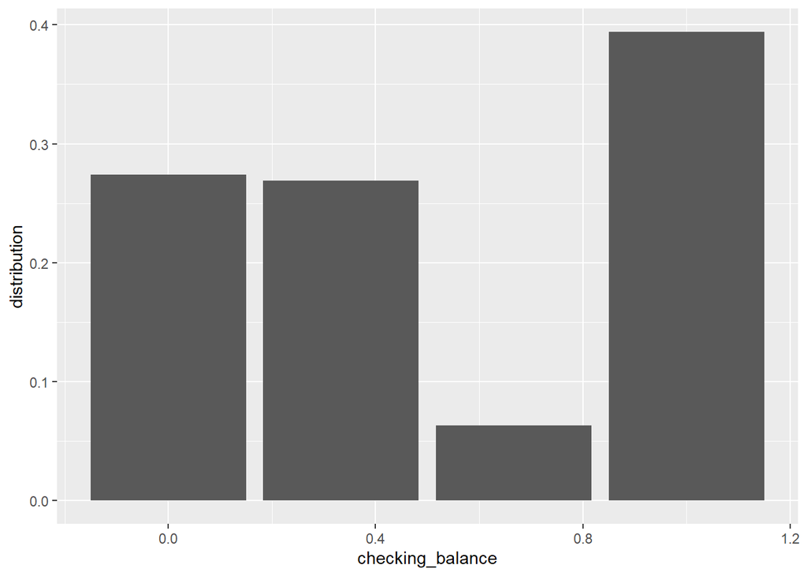

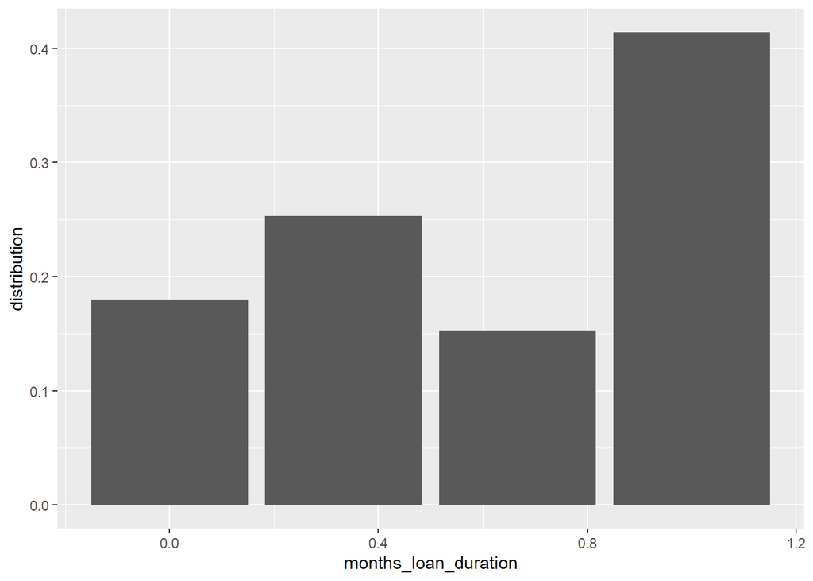

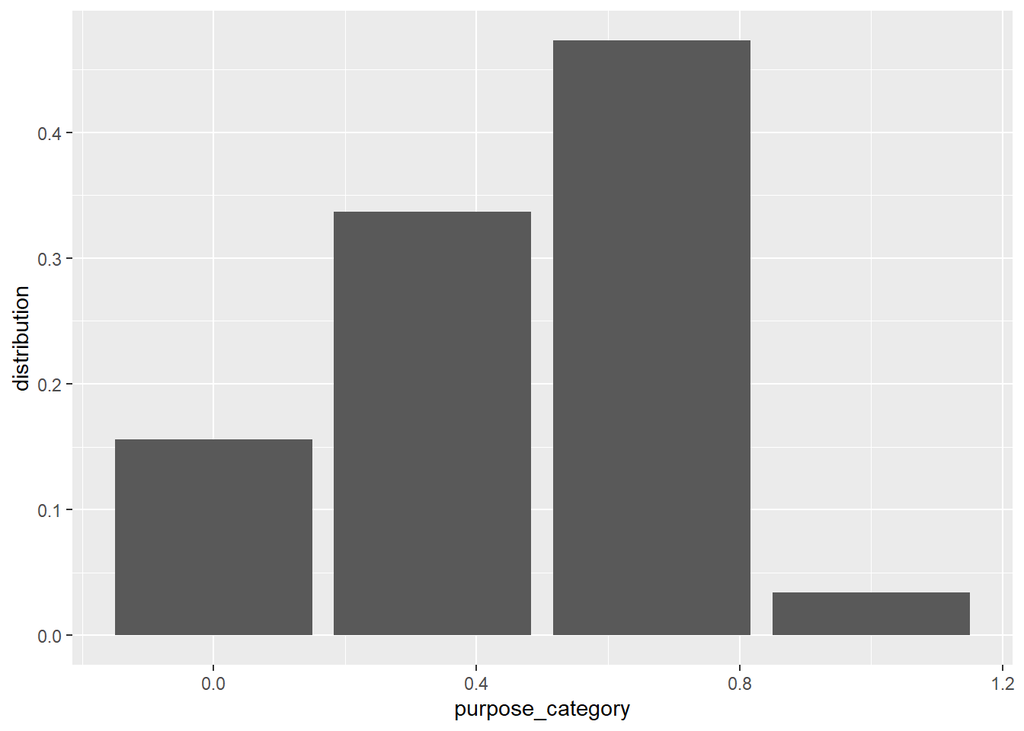

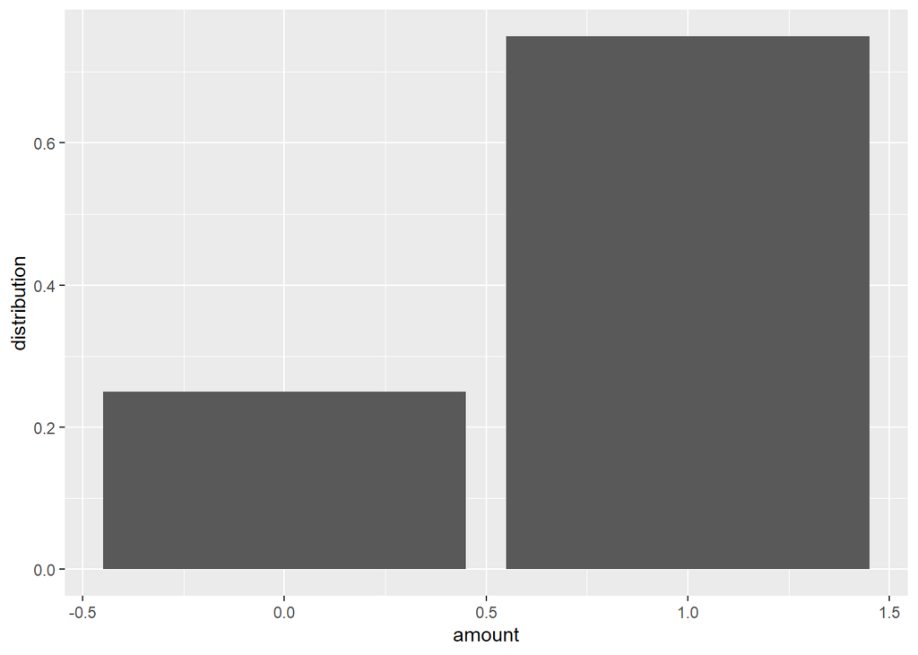

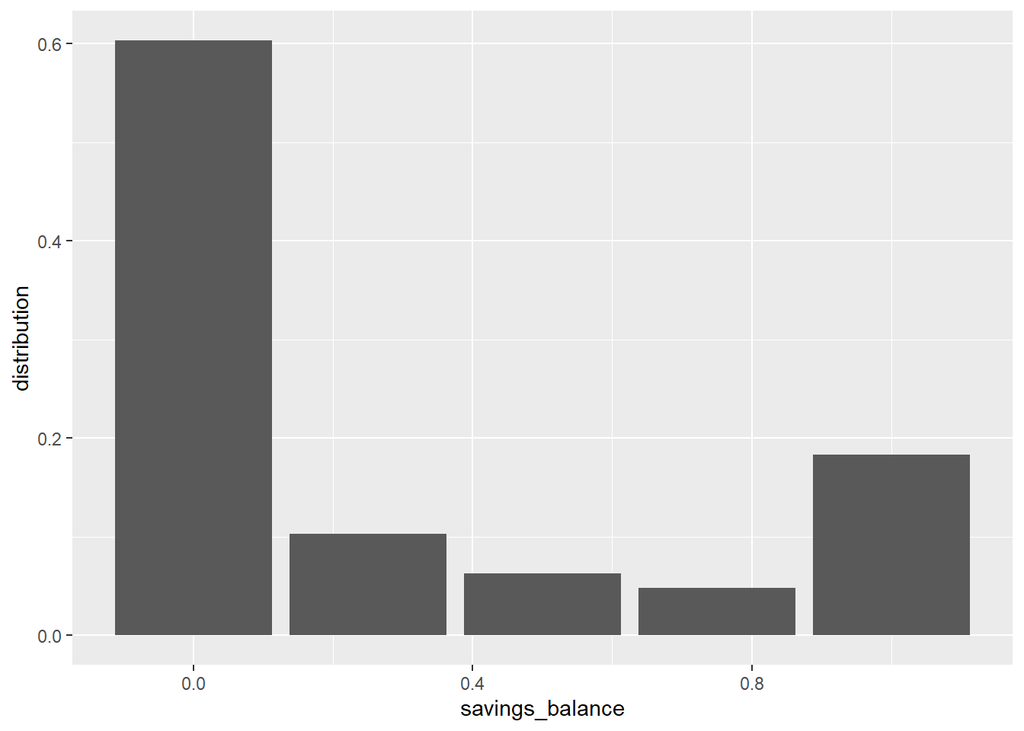

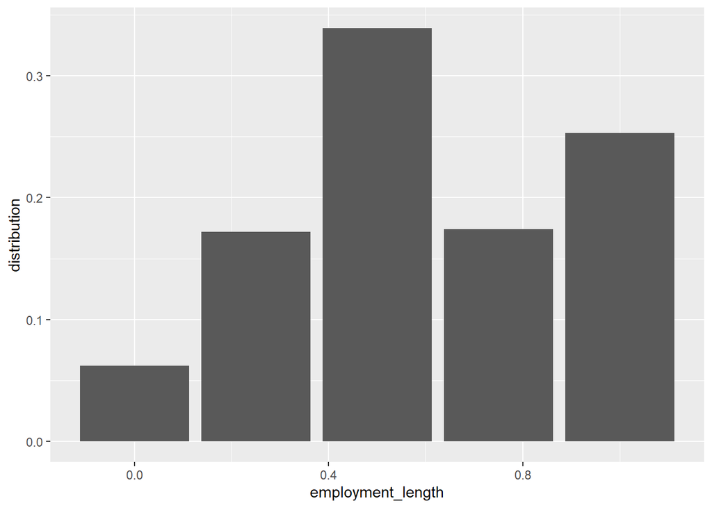

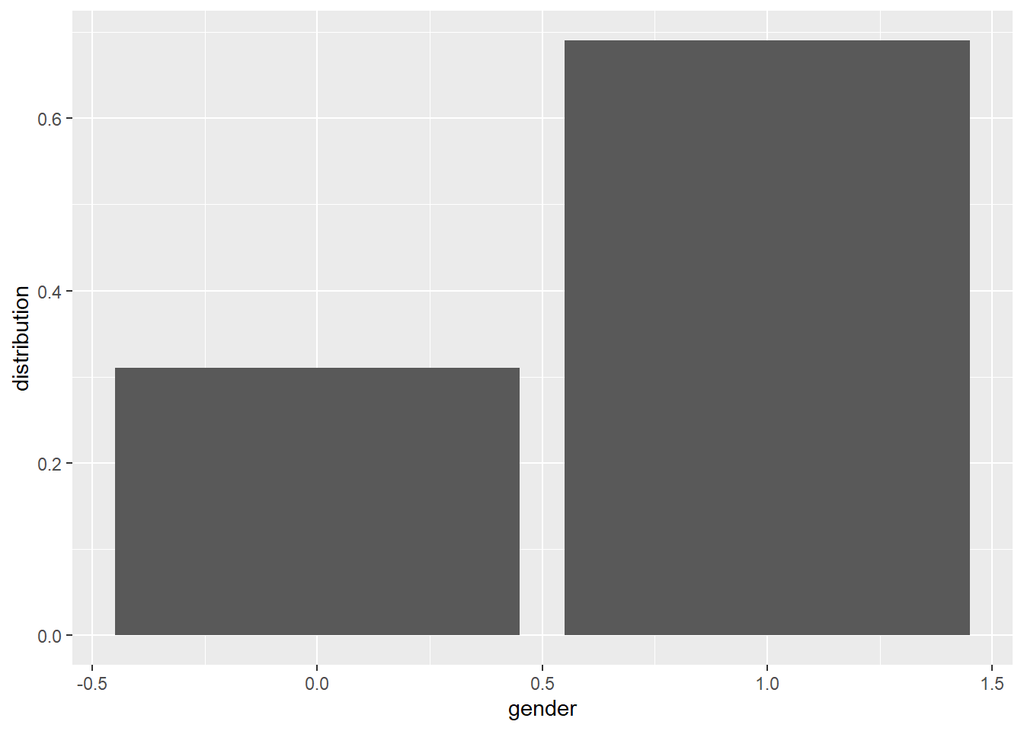

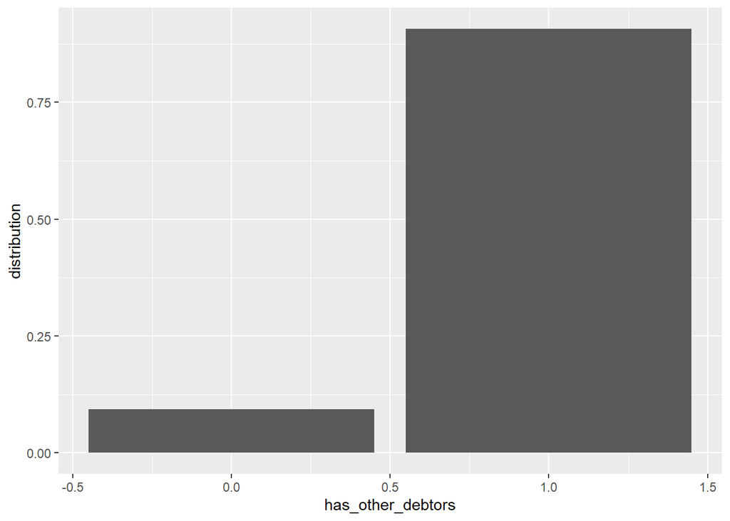

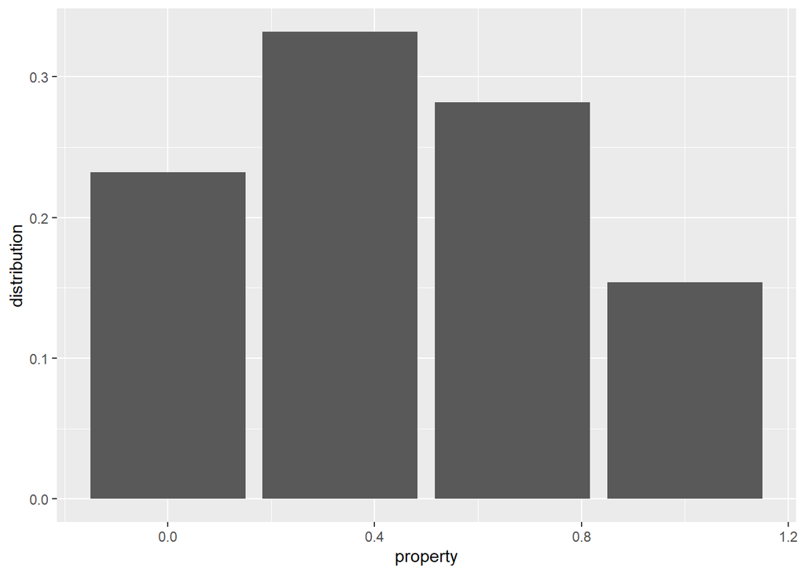

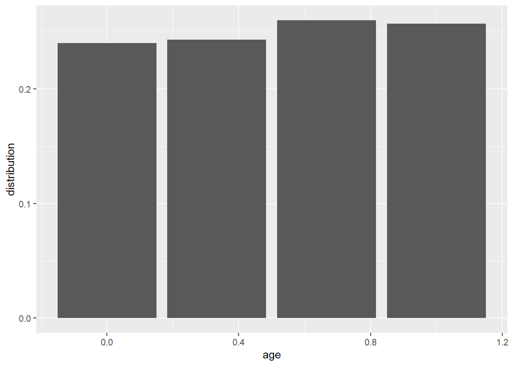

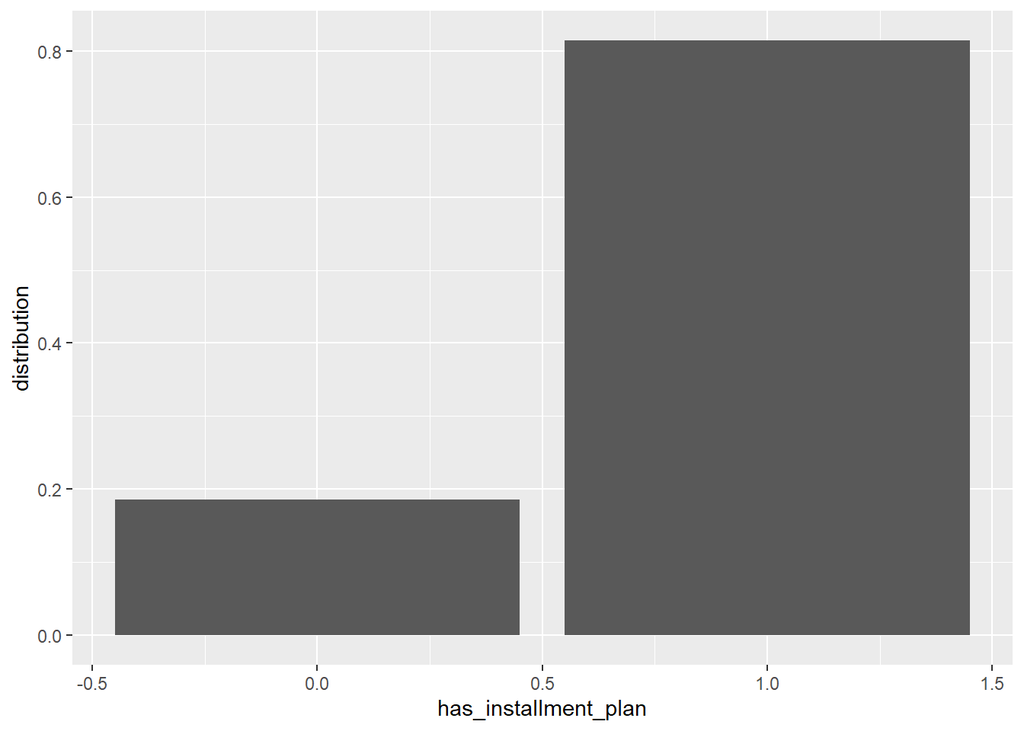

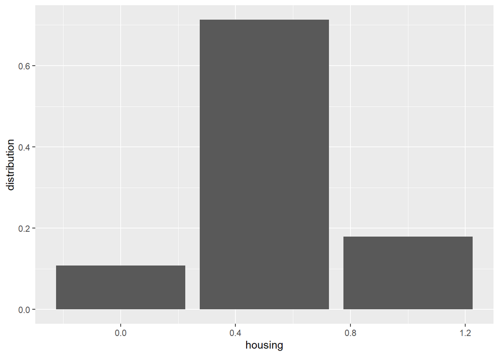

[3 more figures not shown]

```r
for(y in 1:ncol(conjunto_datos_nor)){

  ggp <- ggplot(conjunto_datos_nor[y], aes_string(x = names(conjunto_datos_nor[y]))) +
         geom_bar(aes(y = (..count..)/sum(..count..))) + ylab("distribution")
  print(ggp)

}
```

### 1.3.2 PCA

Tanto el análisis de componentes principales, principal componente analysis (PCA) en inglés, como la descomposición de valores singulares, singular value decomposition (SVD) en inglés, son técnicas que nos permitan trabajar con nuevas características llamadas componentes, que ciertamente son independientes entre sí.

En realidad, estas dos técnicas nos permiten representar el juego de datos en un nuevo sistema de coordenadas que denominamos componentes principales. Este sistema está mejor adaptado a la distribución del juego de datos, de forma que recoge mejor su variabilidad.

#### 1.3.2.1 CRITERIO DE KAISER

Los valores propios se pueden utilizar para determinar el número de componentes principales a retener después de la PCA (Kaiser 1961):

- Un valor propio > 1 indica que los PCs representan más varianza de la que representa una de las variables originales de los datos estandarizados. Esto se utiliza habitualmente como punto de corte para el cual se conservan los PCs. Esto solo es cierto cuando los datos están estandarizados.
- También podemos limitar el número de componentes a este número que representa una determinada fracción de la varianza total. Por ejemplo, si estamos satisfecho con el 80% de la varianza total explicada, usamos el número de componentes para conseguirlo.

#### 1.3.2.2 SELECCIÓN DE DIMENSIONES

Escalamos los datos para una correcta selección de dimensiones:

```r
# Escalamos los datos
acc_scale <- scale(conjunto_datos_nor)

# Calculamos las componentes principales
pca.acc_scale <- prcomp(acc_scale)

# Mostramos la varianza de dichas variables:
var_acc_scale <- pca.acc_scale$sdev^2
head(var_acc_scale)
```

```
## [1] 2.073991 1.536453 1.383254 1.134291 1.076376 1.007576
```

Mostramos el histograma de porcentaje de varianza explicado con los datos escalados

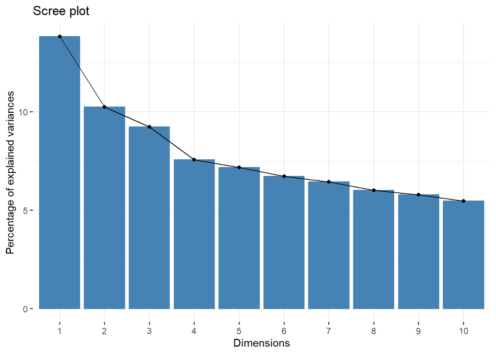

```r
fviz_eig(pca.acc_scale)
```

Seleccionamos las variables a estudiar a partir del criterio de Káiser:

```r
ev = get_eig(pca.acc_scale)
ev
```

```
##        eigenvalue variance.percent cumulative.variance.percent
## Dim.1   2.0739913        13.826608                    13.82661
## Dim.2   1.5364534        10.243022                    24.06963
## Dim.3   1.3832539         9.221693                    33.29132
## Dim.4   1.1342908         7.561939                    40.85326
## Dim.5   1.0763761         7.175841                    48.02910
## Dim.6   1.0075758         6.717172                    54.74628
## Dim.7   0.9655879         6.437253                    61.18353
## Dim.8   0.9002543         6.001695                    67.18522
## Dim.9   0.8660247         5.773498                    72.95872
## Dim.10  0.8189685         5.459790                    78.41851
## Dim.11  0.7534259         5.022839                    83.44135
## Dim.12  0.7354268         4.902845                    88.34420
## Dim.13  0.6812658         4.541772                    92.88597
## Dim.14  0.5972298         3.981532                    96.86750
## Dim.15  0.4698751         3.132500                   100.00000
```

Observamos que las 6 primeras dimensionas tienen un valor superiores a 1. Por lo tanto, éstas serán las seleccionadas.

```r
var <- get_pca_var(pca.acc_scale)
var
```

```
## Principal Component Analysis Results for variables
##  ===================================================
##   Name       Description
## 1 "$coord"   "Coordinates for the variables"
## 2 "$cor"     "Correlations between variables and dimensions"
## 3 "$cos2"    "Cos2 for the variables"
## 4 "$contrib" "contributions of the variables"
```

#### 1.3.2.3 CONTRIBUCIÓN DE LAS VARIABLES

Las variables más importantes (que más contribuyen en cada dimensión) se pueden resaltar de las siguientes maneras:

-Tabla

```r
head(var$contrib[,1:6], ncol(conjunto_datos_nor))
```

```
##                          Dim.1      Dim.2       Dim.3        Dim.4        Dim.5
## checking_balance      2.507825  1.1829677 24.34313014  0.005663765 7.539182e+00
## months_loan_duration  5.440824 34.4058438  0.81789433  1.386257996 7.695909e-02
## purpose_category      3.078767  0.1655214  2.81610823  3.615714406 1.801704e+01
## amount                4.035513 27.5811836  0.55989737  5.127819527 5.373811e+00
## savings_balance       2.775802  0.1178353 21.84305685  0.329816084 1.169017e+01
## employment_length    10.801779  4.2351672  1.48784925  8.606638497 1.150329e-04
## gender               11.349386  1.7471796  1.93864660  9.073854914 1.568076e-01
## has_other_debtors     1.330612  0.3507689 16.64969798 22.214746961 4.205065e+00
## property              6.145970  2.3695281 14.44715704 16.610304359 6.558979e+00
## age                  19.039652  7.8953466  0.07962701  0.509972001 3.597282e-02
## has_installment_plan  1.281391  0.6976374  3.21433115  0.840769411 1.656244e+01
## housing              17.257534  1.8313732  9.04108432 11.787817063 1.400216e+00
## existing_credits      3.926401  1.9991907  0.59306833  7.000078030 2.618098e+01
## telephone             9.544647  6.3086403  1.35035436  0.000207156 5.763393e-02
## foreign_worker        1.483897  9.1118164  0.81809703 12.890339829 2.144637e+00
##                            Dim.6
## checking_balance      1.05713564
## months_loan_duration  0.01570133
## purpose_category     39.18114771
## amount                1.54906106
## savings_balance       3.56755539
## employment_length     4.22846466
## gender                1.97299198
## has_other_debtors     0.32587478
## property              0.38837017
## age                   0.44550305
## has_installment_plan  1.39390692
## housing               0.02980169
## existing_credits      8.70421879
## telephone             0.04720781
## foreign_worker       37.09305904
```

-Gráfica

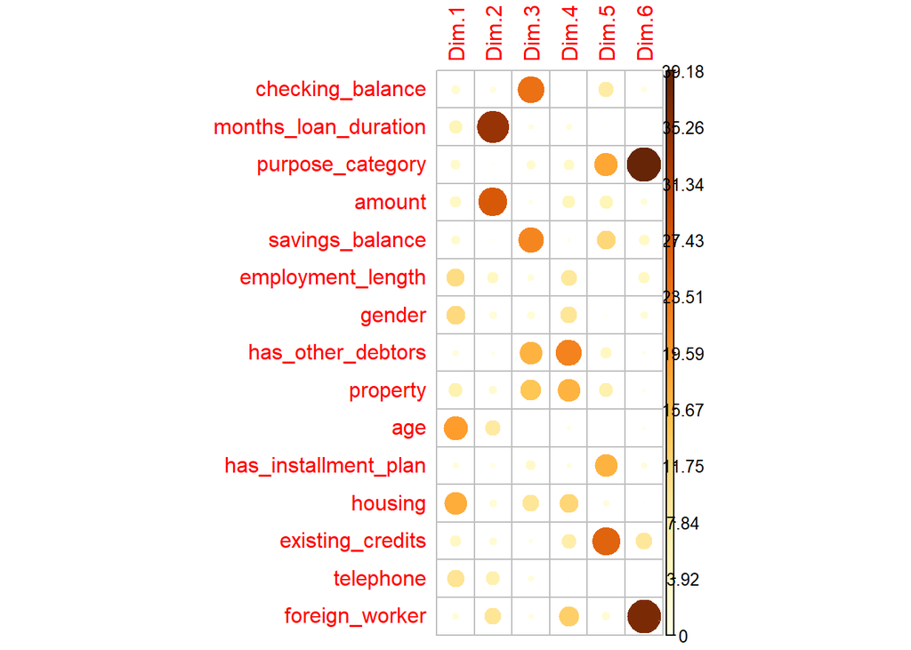

```r
corrplot(var$contrib[,1:6], is.cor=FALSE)
```

…

## 1.4 CONCLUSIONES

…

# 2 EJERCICIO 2

2. Realizar un primer árbol de decisión. Puedes decidir utilizar todas las variables o, de forma justificada, quitar alguna para el ajuste del modelo

## 2.1 LIBRERIAS

```r
if(!require(grid)){
    install.packages('grid', repos='http://cran.us.r-project.org')
    library(grid)
}
if(!require(C50)){
    install.packages('C50', repos='http://cran.us.r-project.org')
    library(C50)
}
```

## 2.2 PREPARACIÓN DE LOS DATOS

Para la futura evaluación del árbol de decisión, es necesario dividir el conjunto de datos en un conjunto de entrenamiento y un conjunto de prueba.

El conjunto de entrenamiento es el subconjunto del conjunto original de datos utilizado para construir un primer modelo; y el conjunto de prueba, el subconjunto del conjunto original de datos utilizado para evaluar la calidad del modelo.

Lo más correcto será utilizar un conjunto de datos diferente del que utilizamos para construir el árbol, es decir, un conjunto diferente del de entrenamiento. No hay ninguna proporción fijada con respecto al número relativo de componentes de cada subconjunto, pero la más utilizada acostumbra a ser 2/3 para el conjunto de entrenamiento y 1/3, para el conjunto de prueba.

```r
conjunto_datos_tree <- conjunto_datos[1:6]
```

```r
y <- conjunto_datos_tree[,4]
X <- conjunto_datos_tree[,-4]
```

De forma dinámica podemos definir una forma de separar los datos en función de un parámetro. Así, definimos un parámetro que controla el split de forma dinámica en el test.

```r
split_prop <- 3
indexes = sample(1:nrow(conjunto_datos_tree), size=floor(((split_prop-1)/split_prop)*nrow(conjunto_datos_tree)))

trainX<-X[indexes,]
trainy<-y[indexes]

testX<-X[-indexes,]
testy<-y[-indexes]
```

```r
summary(trainX)
```

```
##  checking_balance months_loan_duration purpose_category savings_balance
##  Min.   :1.000    Min.   :1.000        Min.   :1.000    Min.   :1.000
##  1st Qu.:1.000    1st Qu.:2.000        1st Qu.:2.000    1st Qu.:1.000
##  Median :2.000    Median :3.000        Median :2.000    Median :1.000
##  Mean   :2.589    Mean   :2.763        Mean   :2.366    Mean   :2.128
##  3rd Qu.:4.000    3rd Qu.:4.000        3rd Qu.:3.000    3rd Qu.:3.000
##  Max.   :4.000    Max.   :4.000        Max.   :4.000    Max.   :5.000
##  employment_length
##  Min.   :1.00
##  1st Qu.:2.25
##  Median :3.00
##  Mean   :3.39
##  3rd Qu.:5.00
##  Max.   :5.00
```

```r
summary(trainy)
```

```
##    Min. 1st Qu.  Median    Mean 3rd Qu.    Max.
##   1.000   1.000   2.000   1.731   2.000   2.000
```

```r
summary(testX)
```

```
##  checking_balance months_loan_duration purpose_category savings_balance
##  Min.   :1.000    Min.   :1.000        Min.   :1.000    Min.   :1.00
##  1st Qu.:1.000    1st Qu.:2.000        1st Qu.:2.000    1st Qu.:1.00
##  Median :2.000    Median :3.000        Median :3.000    Median :1.00
##  Mean   :2.554    Mean   :2.877        Mean   :2.422    Mean   :2.06
##  3rd Qu.:4.000    3rd Qu.:4.000        3rd Qu.:3.000    3rd Qu.:3.00
##  Max.   :4.000    Max.   :4.000        Max.   :4.000    Max.   :5.00
##  employment_length
##  Min.   :1.000
##  1st Qu.:3.000
##  Median :3.000
##  Mean   :3.371
##  3rd Qu.:4.000
##  Max.   :5.000
```

```r
summary(testy)
```

```
##    Min. 1st Qu.  Median    Mean 3rd Qu.    Max.
##   1.000   2.000   2.000   1.787   2.000   2.000
```

Verificamos fácilmente que no hay diferencias graves que puedan sesgar las conclusiones.

## 2.3 CREACIÓN DEL MODELO

Se crea el árbol de decisión usando los datos de entrenamiento (no hay que olvidar que la variable outcome es de tipo factor):

```r
trainy <-  as.factor(trainy)
model <- C50::C5.0(trainX, trainy)
summary(model)
```

```
##
## Call:
## C5.0.default(x = trainX, y = trainy)
##
##
## C5.0 [Release 2.07 GPL Edition]      Wed Dec 27 15:29:43 2023
## -------------------------------
##
## Class specified by attribute `outcome'
##
## Read 666 cases (6 attributes) from undefined.data
##
## Decision tree:
##
## months_loan_duration > 2: 2 (363/41)
## months_loan_duration <= 2:
## :...checking_balance > 3: 2 (122/43)
##     checking_balance <= 3:
##     :...months_loan_duration > 1:
##         :...purpose_category <= 1: 1 (12/4)
##         :   purpose_category > 1: 2 (95/41)
##         months_loan_duration <= 1:
##         :...employment_length > 4: 1 (17/3)
##             employment_length <= 4:
##             :...savings_balance <= 4: 1 (50/19)
##                 savings_balance > 4: 2 (7/1)
##
##
## Evaluation on training data (666 cases):
##
##      Decision Tree
##    ----------------
##    Size      Errors
##
##       7  152(22.8%)   <<
##
##
##     (a)   (b)    <-classified as
##    ----  ----
##      53   126    (a): class 1
##      26   461    (b): class 2
##
##
##  Attribute usage:
##
##  100.00% months_loan_duration
##   45.50% checking_balance
##   16.07% purpose_category
##   11.11% employment_length
##    8.56% savings_balance
##
##
## Time: 0.0 secs
```

Errors muestra el número y porcentaje de casos mal clasificados en el subconjunto de entrenamiento.

## 2.4 ÁRBOL OBTENIDO

A continuación, mostramos el árbol obtenido.

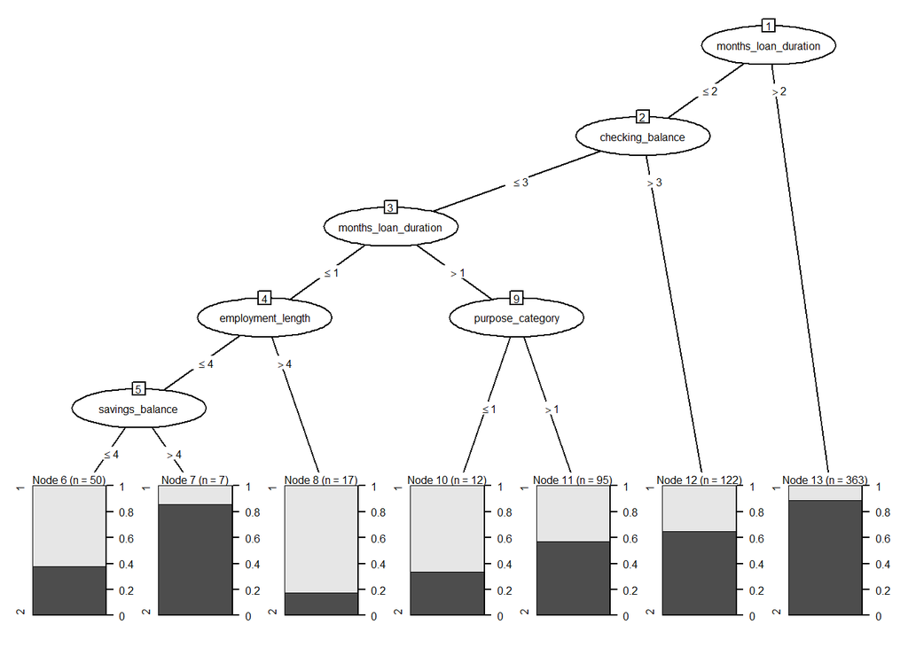

```r
plot(model,gp = gpar(fontsize = 6))
```

# 3 EJERCICIO 3

3. Con el árbol obtenido, realiza una breve explicación de las reglas obtenidas así como de todos los puntos que te parezcan interesantes. Un elemento a considerar es, por ejemplo, cuantas observaciones caen dentro de cada regla.

### 3.0.1 REGLAS

#### 3.0.1.1 CODIFICACIÓN

```r
trainy <-  as.factor(trainy)
model <- C5.0(trainX, trainy, rules=TRUE )
summary(model)
```

```
##
## Call:
## C5.0.default(x = trainX, y = trainy, rules = TRUE)
##
##
## C5.0 [Release 2.07 GPL Edition]      Wed Dec 27 15:29:44 2023
## -------------------------------
##
## Class specified by attribute `outcome'
##
## Read 666 cases (6 attributes) from undefined.data
##
## Rules:
##
## Rule 1: (12/4, lift 2.4)
##  checking_balance <= 3
##  months_loan_duration > 1
##  months_loan_duration <= 2
##  purpose_category <= 1
##  ->  class 1  [0.643]
##
## Rule 2: (181/86, lift 2.0)
##  checking_balance <= 3
##  months_loan_duration <= 2
##  ->  class 1  [0.525]
##
## Rule 3: (34/4, lift 1.2)
##  checking_balance <= 3
##  savings_balance > 4
##  employment_length <= 4
##  ->  class 2  [0.861]
##
## Rule 4: (539/113, lift 1.1)
##  months_loan_duration > 1
##  ->  class 2  [0.789]
##
## Rule 5: (266/60, lift 1.1)
##  checking_balance > 3
##  ->  class 2  [0.772]
##
```

[output cut: 13 more lines]

```
##    ----  ----
##      52   127    (a): class 1
##      26   461    (b): class 2
##
##
##  Attribute usage:
##
##   92.04% months_loan_duration
##   70.12% checking_balance
##    5.11% savings_balance
##    5.11% employment_length
##    1.80% purpose_category
##
##
## Time: 0.0 secs
```

#### 3.0.1.2 ANÁLISIS

La extracción de las reglas anteriores nos permite identificar los posibles perfiles de prestatarios en función de la cantidad de dinero que solicitan para el préstamo.

##### 3.0.1.2.1 CANTIDAD INFERIOR A 1300

**Regla 1**

**Regla 2**

**Regla 3**

##### 3.0.1.2.2 CANTIDAD SUPERIOR A 1300

**Regla 4**

**Regla 5**

# 4 EJERCICIO 4

4. Una vez tengas un modelo válido, procede a realizar un análisis de la bondad de ajuste sobre el conjunto de test y matriz de confusión. ¿Te parece un modelo suficientemente bueno como para utilizarlo? Justifica tu respuesta considerando todos los posibles tipos de error

## 4.1 LIBRERIAS

```r
if(!require(gmodels)){
    install.packages('gmodels', repos='http://cran.us.r-project.org')
    library(gmodels)
}
```

## 4.2 VALIDACIÓN DEL MODELO

Una vez tenemos el modelo, podemos comprobar su calidad prediciendo la clase para los datos de prueba que nos hemos reservado al principio.

### 4.2.1 PRECISIÓN DEL ÁRBOL

```r
predicted_model <- predict( model, testX, type="class" )
print(sprintf("La precisión del árbol es: %.4f %%",100*sum(predicted_model == testy) / length(predicted_model)))
```

```
## [1] "La precisión del árbol es: 79.0419 %"
```

### 4.2.2 MATRIZ DE CONFUSIÓN

Cuando hay pocas clases, la calidad de la predicción se puede analizar mediante una matriz de confusión que identifica los tipos de errores cometidos.

```r
mat_conf<-table(testy,Predicted=predicted_model)
```

La podemos emplear para calcular el porcentaje de registros correctamente clasificados:

```r
porcentaje_correct <- 100 * sum(diag(mat_conf)) / sum(mat_conf)
print(sprintf("El %% de registros correctamente clasificados es: %.4f %%",porcentaje_correct))
```

```
## [1] "El % de registros correctamente clasificados es: 79.0419 %"
```

Además, tenemos a nuestra disposición el paquete gmodels para obtener información más completa:

```r
CrossTable(testy, predicted_model,prop.chisq  = FALSE, prop.c = FALSE, prop.r =FALSE,dnn = c('Reality', 'Prediction'))
```

```
##
##
##    Cell Contents
## |-------------------------|
## |                       N |
## |         N / Table Total |
## |-------------------------|
##
##
## Total Observations in Table:  334
##
##
##              | Prediction
##      Reality |         1 |         2 | Row Total |
## -------------|-----------|-----------|-----------|
##            1 |        16 |        55 |        71 |
##              |     0.048 |     0.165 |           |
## -------------|-----------|-----------|-----------|
##            2 |        15 |       248 |       263 |
##              |     0.045 |     0.743 |           |
## -------------|-----------|-----------|-----------|
## Column Total |        31 |       303 |       334 |
## -------------|-----------|-----------|-----------|
##
##
```